# team

Rushal Sohal, Rohan Mishra; github: rsohal, rohmish

2/26/2020

## Lab 3

```r
if(!require("readxl")){
  install.packages('readxl')
  install.packages("ggplot2")
  install.packages("dplyr")
  install.packages("ggmosaic")
}
library(dplyr)
library(ggmosaic)
library(ggplot2)
```

```r
dat <- readxl::read_xls('/Users/rushalsohal/Desktop/Rushal/Sophomore_Spring2020/GSS.xls')
names(dat) <- c('year', 'id', 'work_hrs', 'marital_status', 'num_children','sex', 'pol_party', 'happy', 'ballot')
```

### **1.**

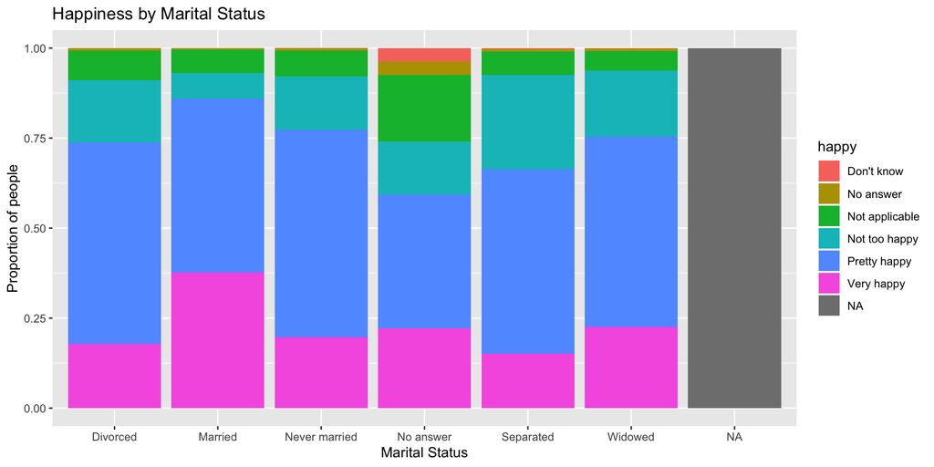

```r
tmp <- dat %>% select(marital_status, happy)
ggplot(data = tmp, aes(x = marital_status, fill = happy)) + geom_bar(position = "fill") + ggtitle("Happiness by Marital Status") + xlab("Marital Status") + ylab("Proportion of people")
```

## **2.**

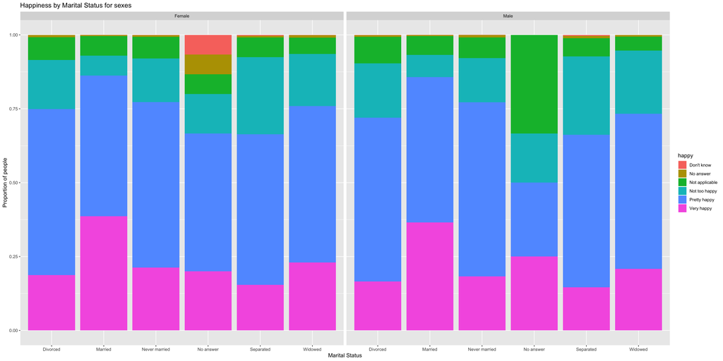

```r
tmp <- na.omit(dat) %>% select(marital_status, happy, sex)
ggplot(data = tmp, aes(x = marital_status, fill = happy)) +
  geom_bar(position = "fill") +
  facet_wrap(~sex) +
  ggtitle("Happiness by Marital Status for sexes") +
  xlab("Marital Status") +
  ylab("Proportion of people")
```

## **3.**

```r
dat$pol_party <- factor(dat$pol_party, levels = c("Strong democrat","Not str democrat", "Ind,near dem", "Strong republican","Not st republican", "Ind,near rep", "Independent", "Other party", "Don't know"))
counts <- dat %>% group_by(happy, pol_party) %>% summarise(counts = n())
```

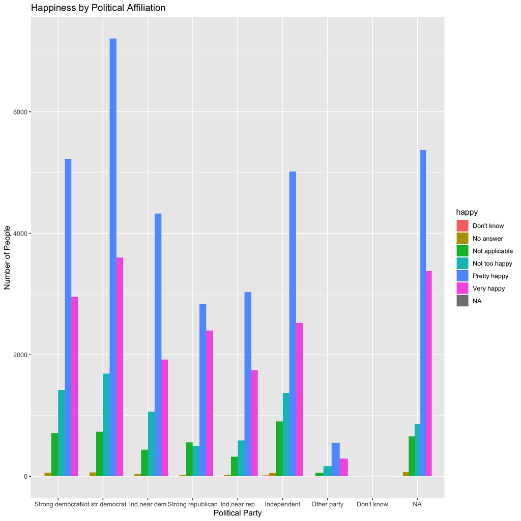

```r
ggplot(data = counts, aes(x = pol_party, y = counts, fill = happy)) +
geom_bar(stat = "identity", position = position_dodge()) +
ggtitle("Happiness by Political Affiliation") + xlab("Political Party") + ylab("Number of People")
```

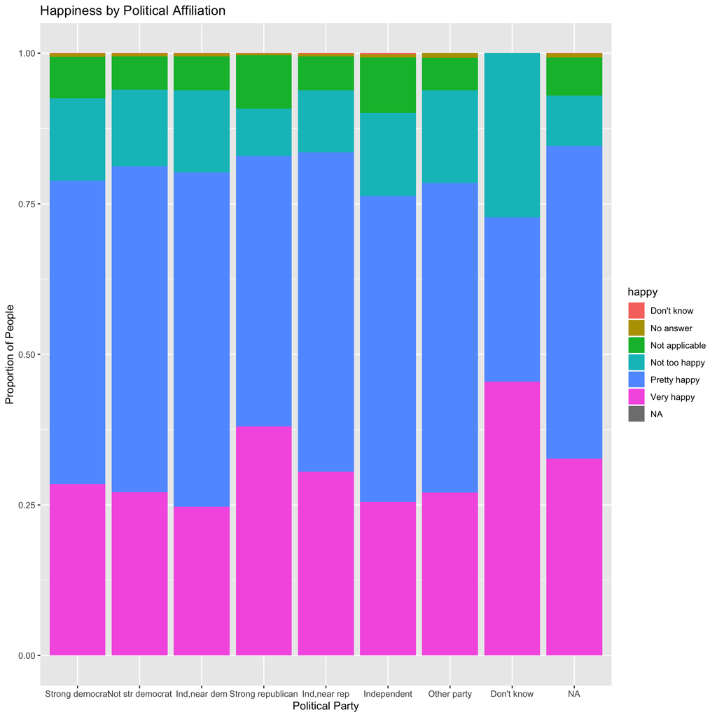

```r
ggplot(data = dat, aes(x = pol_party, fill = happy)) + geom_bar(position = "fill") + ggtitle("Happiness by Political Affiliation") + xlab("Political Party") + ylab("Proportion of People")
```

There are more not strong democrats who are happy. Percentage wise, Ind,near rep tend to be overall happy compared to other political affiliations. Strong republicans are the least unhappy.

## **4.**

### *a.* How do the number of children affect happiness?

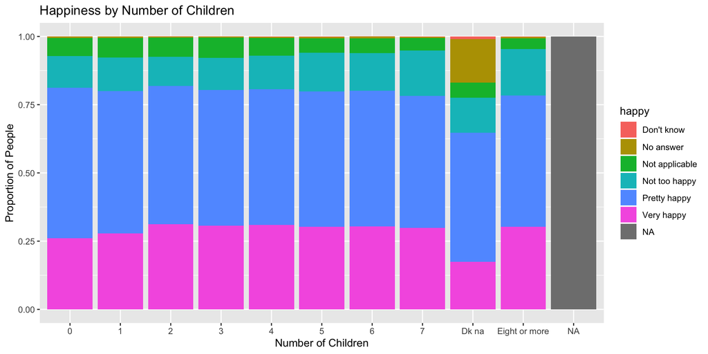

```r
ggplot(data = dat, aes(x = num_children, fill = happy)) + geom_bar(position = "fill") + ggtitle("Happiness by Number of Children") + xlab("Number of Children") + ylab("Proportion of People")
```

### *b.* Does the sex of the respondent affect their political affiliation?

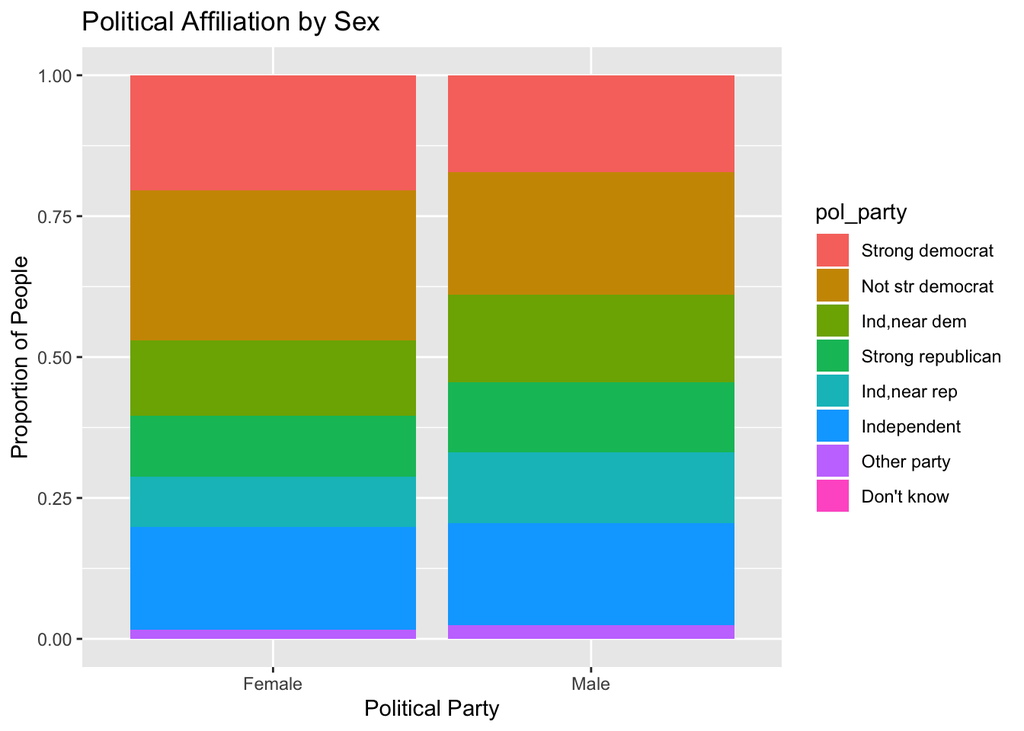

```r
ggplot(data = na.omit(dat), aes(x = sex, fill = pol_party)) + geom_bar(position = "fill") + ggtitle("Political Affiliation by Sex") + xlab("Political Party") + ylab("Proportion of People")
```

The political party distribution is about the same for both sexes. Nevertheless, we can say that females have a higher distribution/ spread of “strong democrat” vs “not str democrat”.

### *c.* How are political affiliations realted to marital status?

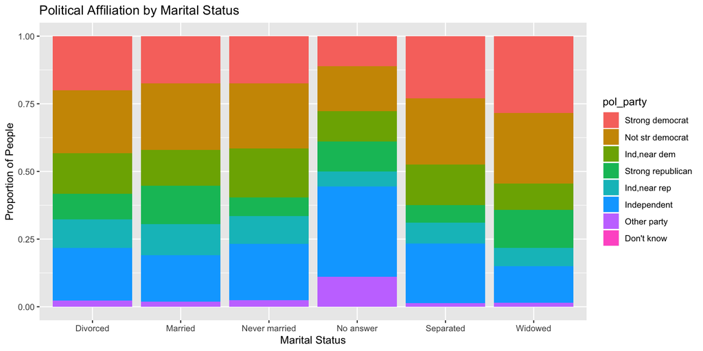

```r
ggplot(data = na.omit(dat), aes(x = marital_status, fill = pol_party)) + geom_bar(position = "fill") + ggtitle("Political Affiliation by Marital Status") + xlab("Marital Status") + ylab("Proportion of People")
```

Widowed people tend to be strong democrats, not str democrats, and strong republicans, thus showing extreme political affiliations. Separated people tend to be more be independent candidates.

### *d.* Does the number of children affect political affiliation?

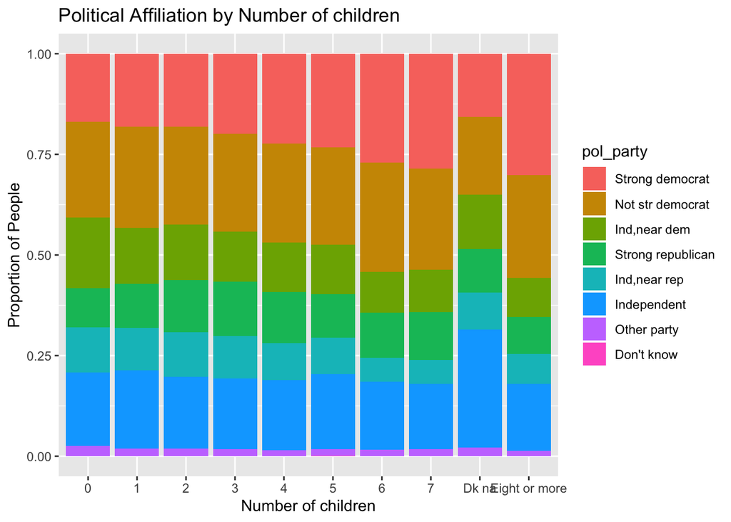

```r
ggplot(data = na.omit(dat), aes(x = num_children, fill = pol_party)) + geom_bar(position = "fill") + ggtitle("Political Affiliation by Number of children") + xlab("Number of children") + ylab("Proportion of People")
```

As the number of children increase, people tend to be stronger democrats.

*We wanted to use Work_hrs, however, the data values showed N/A*